# Bellabeat Case Study

Abhinav Pangaria

2024-07-02

## ASK (Business need and the questions to be answered)

**Business Task:**

*Analyze smart device usage data to gain insights into how consumers use non-Bellabeat smart devices, and apply these insights specifically to the Bellabeat Time watch. The goal is to inform Bellabeat’s marketing strategy for this product.*

**Key Questions to Address:**

*What are some trends in smart device usage, particularly related to activity tracking, sleep monitoring, and stress management?*

*How could these trends apply to Bellabeat Time watch customers?*

*How could these trends help influence Bellabeat’s marketing strategy for the Time watch?*

**Key Stakeholders:**

*Urška Sršen: Bellabeat’s cofounder and Chief Creative Officer.*

*Sando Mur: Mathematician and Bellabeat’s cofounder; key member of the Bellabeat executive team.*

*Bellabeat marketing analytics team.*

**Deliverables:**

*A clear summary of the business task.*

*A description of all data sources used.*

*Documentation of any cleaning or manipulation of data.*

*A summary of the analysis.*

*Supporting visualizations and key findings.*

*Top high-level content recommendations for marketing the Time watch based on the analysis.*

**Data Source:** https://www.kaggle.com/arashnic/fitbit

**Data used in the study:** The data used is from a fit-bit tracking dataset that contains the daily activity records, hourly managed calories, weight loss and sleep tracking information provided by mobius.

### Data stats:

**Daily activity data.**

```
##    TotalSteps    TotalDistance    SedentaryMinutes
##  Min.   :    0   Min.   : 0.000   Min.   :  32.0
##  1st Qu.: 1988   1st Qu.: 1.410   1st Qu.: 728.0
##  Median : 5986   Median : 4.090   Median :1057.0
##  Mean   : 6547   Mean   : 4.664   Mean   : 995.3
##  3rd Qu.:10198   3rd Qu.: 7.160   3rd Qu.:1285.0
##  Max.   :28497   Max.   :27.530   Max.   :1440.0
```

**Steps data.**

```
##    StepTotal
##  Min.   :    0.0
##  1st Qu.:    0.0
##  Median :   10.0
##  Mean   :  286.2
##  3rd Qu.:  289.0
##  Max.   :10565.0
```

**Weight loss data.**

```
##     WeightKg           BMI
##  Min.   : 53.30   Min.   :21.45
##  1st Qu.: 61.70   1st Qu.:24.10
##  Median : 62.50   Median :24.39
##  Mean   : 73.44   Mean   :25.73
##  3rd Qu.: 85.80   3rd Qu.:25.76
##  Max.   :129.60   Max.   :46.17
```

**Sleep data.**

```
##  TotalMinutesAsleep TotalTimeInBed
##  Min.   : 58.0      Min.   : 61.0
##  1st Qu.:361.0      1st Qu.:403.0
##  Median :433.0      Median :463.0
##  Mean   :419.5      Mean   :458.6
##  3rd Qu.:490.0      3rd Qu.:526.0
##  Max.   :796.0      Max.   :961.0
```

**Additional data preparing:**

As the provided data is an hourly recorded data we need to merge them on the basis of individual user thus we have aggregated activity, steps, calories, weight loss.

Combined data for the distance covered, steps taken, sleep, sedentary time is created so that there can be visualisations based on relations between the data. Many of the users did not have sufficient data and thus they needed to be cleaned out for this combined analysis. Their individual usage has been kept as original data.

```
##        Id            TotalCalories   TotalDistance    TotalSedentaryMin
##  Min.   :1.504e+09   Min.   :14442   Min.   :  0.00   Min.   : 7293
##  1st Qu.:2.610e+09   1st Qu.:19260   1st Qu.: 25.36   1st Qu.: 9261
##  Median :4.445e+09   Median :24884   Median : 52.19   Median :11074
##  Mean   :4.845e+09   Mean   :28588   Mean   : 60.89   Mean   :12996
##  3rd Qu.:6.869e+09   3rd Qu.:31571   3rd Qu.: 87.06   3rd Qu.:12908
##  Max.   :8.878e+09   Max.   :98412   Max.   :169.09   Max.   :43458
```

```
##        Id                Weight            BMI
##  Min.   :1.504e+09   Min.   : 53.30   Min.   :21.55
##  1st Qu.:2.610e+09   1st Qu.: 62.63   1st Qu.:24.46
##  Median :4.445e+09   Median : 75.60   Median :25.68
##  Mean   :4.486e+09   Mean   : 79.67   Mean   :28.01
##  3rd Qu.:5.833e+09   3rd Qu.: 90.40   3rd Qu.:28.34
##  Max.   :8.878e+09   Max.   :129.60   Max.   :46.17
```

```
##        Id              TotalSteps
##  Min.   :1.504e+09   Min.   :   360
##  1st Qu.:2.479e+09   1st Qu.:115365
##  Median :4.502e+09   Median :183138
##  Mean   :4.858e+09   Mean   :202744
##  3rd Qu.:6.916e+09   3rd Qu.:257984
##  Max.   :8.878e+09   Max.   :534197
```

```
##        Id            TotalCalories
##  Min.   :1.504e+09   Min.   :  1120
##  1st Qu.:2.479e+09   1st Qu.: 56488
##  Median :4.502e+09   Median : 62437
##  Mean   :4.858e+09   Mean   : 66774
##  3rd Qu.:6.916e+09   3rd Qu.: 82490
##  Max.   :8.878e+09   Max.   :109928
```

```
##        Id            TotalSleepMinutes  TotalBedTime
##  Min.   :1.504e+09   Min.   :   61     Min.   :   69
##  1st Qu.:2.340e+09   1st Qu.: 1761     1st Qu.: 1988
##  Median :4.502e+09   Median : 8420     Median : 9382
##  Mean   :4.764e+09   Mean   : 7218     Mean   : 7892
##  3rd Qu.:6.822e+09   3rd Qu.:11372     3rd Qu.:12509
##  Max.   :8.792e+09   Max.   :14368     Max.   :15682
```

## **Daily activity visualisation:**

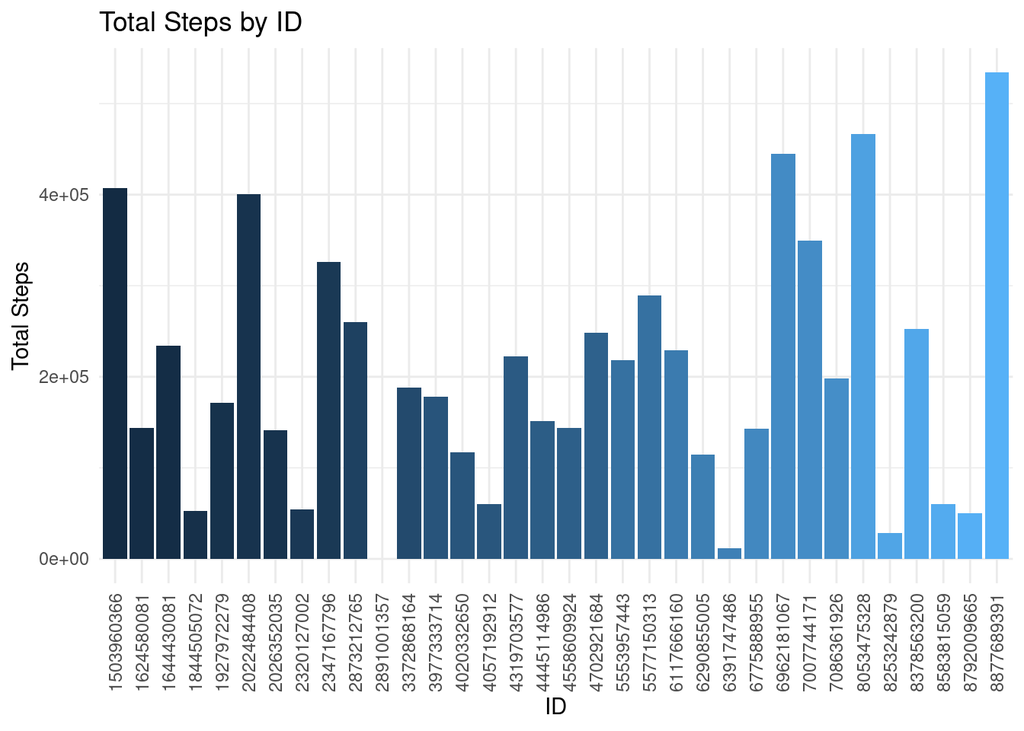

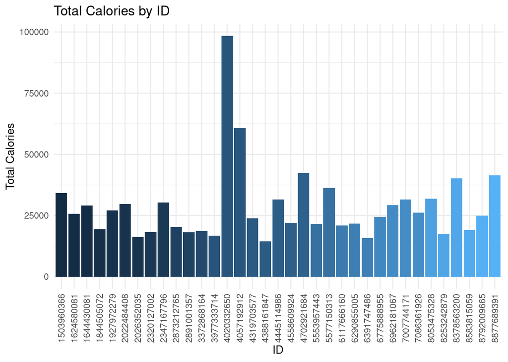

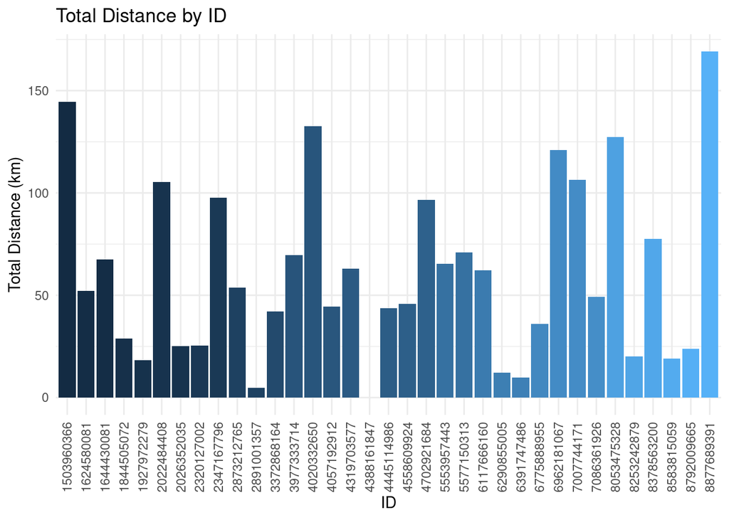

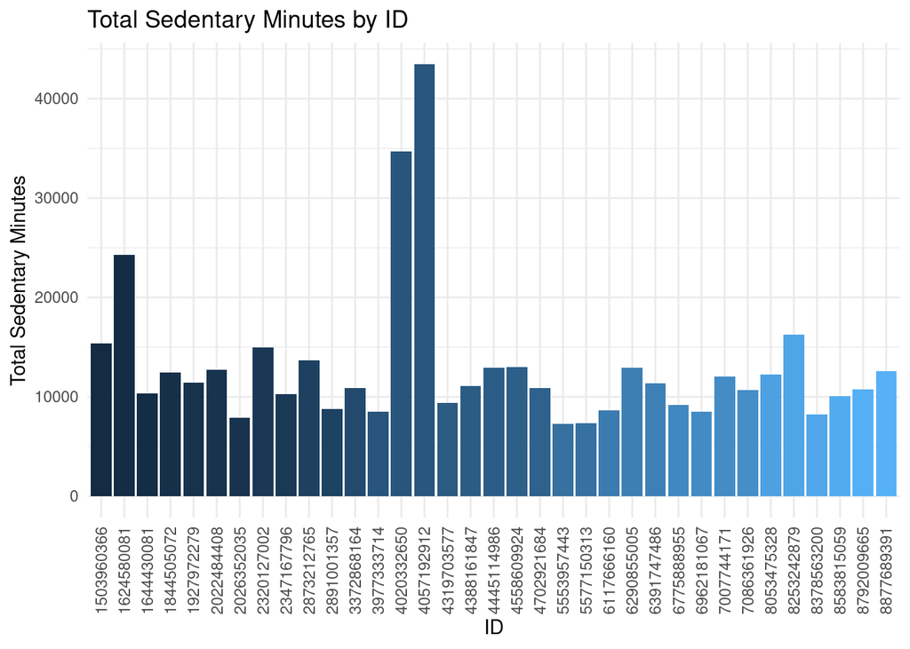

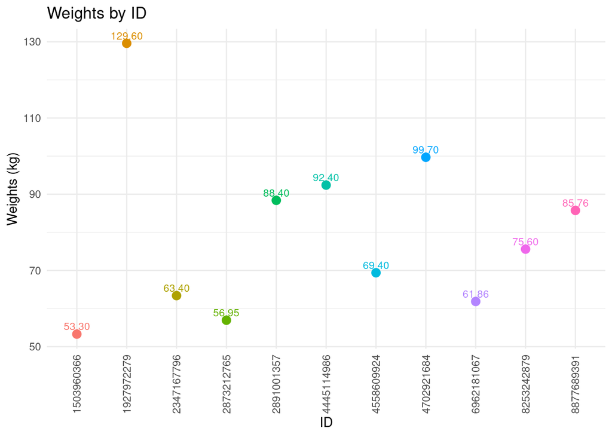

## Relations and Plots:

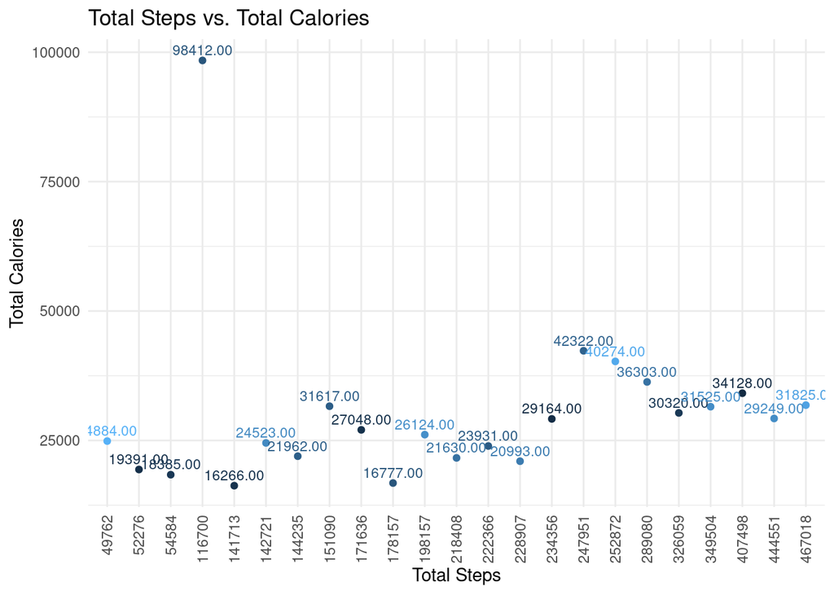

**Remarks:** We see that in a pattern that more calories are burned for more steps taken.

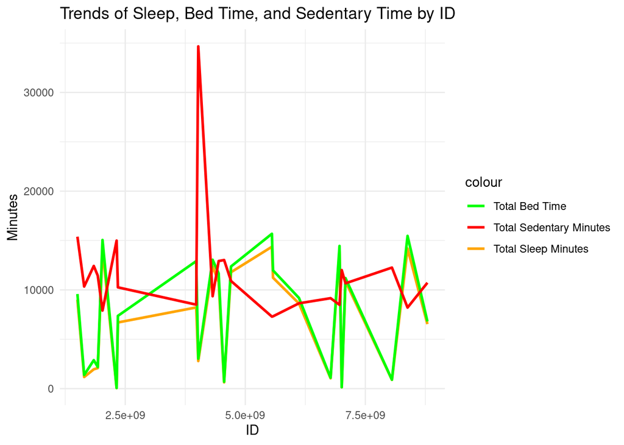

**Remarks:** The line plot invigorates the idea that the users tend to have simila bed time and sleep time that means that the users do not indulge in bed time a lot. This also conveys that the users tend to have a suffice sleep during all their bed time duration.

### Plotting the relation between steps, sleep and sedentary minutes for a user.

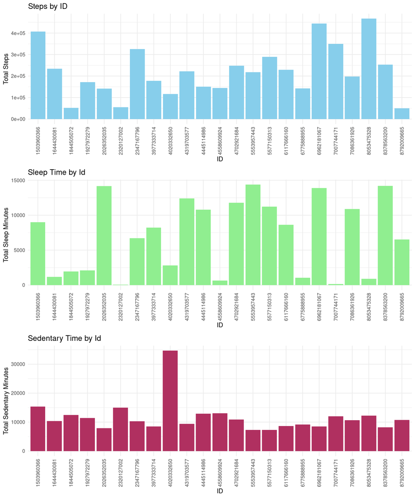

## **Conclusion:**

The usage of the fitbit tracker watch revels the underlying mindset of the user to keep a track of all the activities that the user consumes during a particular time period. The user tends to have a keen interest in tracking the sleep time, track the step count and also most of all know the calories that they intake and the subsequent result of the usage to their health and fitness.

The Time watch can be marketed to be more precise at gathering the data with an emphasis on the fitness and health part. Sleep can be used as a underlying support factor to push the product to have an accurate sleep tracker that allows the user to plan a better sleep routine thus in turn have a health benefit.

A more detailed emphasis would be:

### **Insights from the Data:**

```
Activity Tracking Trends:
  Users exhibit varying levels of activity, with some achieving high step counts and distances.

Caloric and Weight Insights:
  There's a correlation between activity levels and calories burned, influencing weight management goals.

Sleep Patterns:
  Users generally maintain consistent bedtimes and sleep durations, which could impact overall health and activity levels.

Sedentary Behavior:
  Many users have significant sedentary time, suggesting opportunities for promoting more active lifestyles.
```

### **Implications for Bellabeat Time Watch:**

```
Enhanced Activity Tracking:
  Emphasize the watch's ability to track steps accurately and provide insights into daily activity levels.

Sleep Monitoring:
  Highlight the watch's sleep tracking capabilities to help users understand their sleep patterns and improve sleep             quality.

Caloric Insights:
  Integrate features that provide users with real-time caloric expenditure data to aid in weight management efforts.

Stress Management:
  Consider adding stress management features, leveraging data on sedentary behavior and sleep quality.
```

### **Marketing Strategy Recommendations:**

```
Targeted Marketing Campaigns:
    Create campaigns emphasizing the Time watch's unique features in activity tracking and sleep monitoring.
    Tailor messaging to highlight health benefits, such as improved sleep quality and stress reduction.


Influencer Partnerships:
    Collaborate with fitness influencers and health professionals to endorse the watch's benefits.
    Utilize user testimonials to build credibility and trust among potential customers.


Digital Marketing and Social Media:
    Leverage social media platforms to showcase user success stories and feature interactive content about fitness tips           and sleep hygiene.
    Use targeted digital ads based on user demographics interested in health and wellness.


Educational Content:
    Develop blogs, videos, and webinars focusing on fitness tips, sleep health, and the benefits of activity tracking.
    Position Bellabeat as a thought leader in holistic health and wellness.
```

### **Next Steps for Bellabeat Owners and Marketing Team:**

```
Product Development:
    Continue refining the Time watch's features based on user feedback and emerging health trends.
    Explore partnerships with health research institutions for continuous improvement and validation of health monitoring         capabilities.

Customer Engagement:
    Implement a customer feedback loop to gather insights and improve user experience.
    Offer personalized coaching services or health challenges through the watch's app to enhance user engagement.

Market Expansion:
    Identify new market segments, such as corporate wellness programs or health insurance partnerships, to expand the             watch's reach.
    Consider international markets and adapt marketing strategies to local health and wellness trends.

Measurement and Evaluation:
    Set clear performance metrics for marketing campaigns and regularly evaluate ROI.
    Use data analytics to track user engagement with the Time watch app and adjust marketing strategies accordingly.
```